# Decision Trees Assignment

### Step 6: Per-Class Performance Analysis

```r
# Generate confusion matrix
test_conf_matrix <- table(Predicted = pred_reduced$predictions, Actual = test_imputed_reduced$class)

# Calculate per-class metrics
per_class_metrics <- data.frame(
  Class = colnames(test_conf_matrix),
  Precision = diag(test_conf_matrix) / colSums(test_conf_matrix),
  Recall = diag(test_conf_matrix) / rowSums(test_conf_matrix)
)

# Add F1 score
per_class_metrics$F1 <- 2 * (per_class_metrics$Precision * per_class_metrics$Recall) /
                         (per_class_metrics$Precision + per_class_metrics$Recall)

# Add support (number of instances)
per_class_metrics$Support <- table(test_imputed_reduced$class)[per_class_metrics$Class]

# Replace NaN values with 0
per_class_metrics[is.na(per_class_metrics)] <- 0

# Sort by support (frequency)
per_class_metrics <- per_class_metrics[order(-per_class_metrics$Support), ]

# Display top 10 classes by frequency
head(per_class_metrics, 10)
```

```
##                           Class Precision    Recall        F1 Support
## b'smurf.'             b'smurf.' 0.9997195 0.9991159 0.9994176   46345
## b'neptune.'         b'neptune.' 0.9990793 0.9987305 0.9989048   31497
## b'normal.'           b'normal.' 0.9984311 0.9945822 0.9965029   28683
## b'back.'               b'back.' 0.9736025 0.9968203 0.9850746     644
## b'satan.'             b'satan.' 0.8391304 0.9578164 0.8945539     460
## b'ipsweep.'         b'ipsweep.' 0.9699454 0.9726027 0.9712722     366
## b'warezclient.' b'warezclient.' 0.8859060 0.9850746 0.9328622     298
## b'portsweep.'     b'portsweep.' 0.8581081 0.8466667 0.8523490     296
## b'teardrop.'       b'teardrop.' 0.9619377 1.0000000 0.9805996     289
## b'pod.'                 b'pod.' 0.9473684 1.0000000 0.9729730      76
```

```r
# Calculate macro average (unweighted mean of all classes)
macro_avg <- data.frame(
  Class = "macro_avg",
  Precision = mean(per_class_metrics$Precision, na.rm = TRUE),
  Recall = mean(per_class_metrics$Recall, na.rm = TRUE),
  F1 = mean(per_class_metrics$F1, na.rm = TRUE),
  Support = sum(per_class_metrics$Support)
)

# Calculate weighted average (weighted by support)
weighted_avg <- data.frame(
  Class = "weighted_avg",
  Precision = sum(per_class_metrics$Precision * per_class_metrics$Support, na.rm = TRUE) /
              sum(per_class_metrics$Support, na.rm = TRUE),
  Recall = sum(per_class_metrics$Recall * per_class_metrics$Support, na.rm = TRUE) /
           sum(per_class_metrics$Support, na.rm = TRUE),
  F1 = sum(per_class_metrics$F1 * per_class_metrics$Support, na.rm = TRUE) /
        sum(per_class_metrics$Support, na.rm = TRUE),
  Support = sum(per_class_metrics$Support)
)

# Combine all metrics
all_metrics <- rbind(per_class_metrics, macro_avg, weighted_avg)
print(all_metrics)
```

```
##                                   Class Precision    Recall        F1 Support
## b'smurf.'                     b'smurf.' 0.9997195 0.9991159 0.9994176   46345
## b'neptune.'                 b'neptune.' 0.9990793 0.9987305 0.9989048   31497
## b'normal.'                   b'normal.' 0.9984311 0.9945822 0.9965029   28683
## b'back.'                       b'back.' 0.9736025 0.9968203 0.9850746     644
## b'satan.'                     b'satan.' 0.8391304 0.9578164 0.8945539     460
## b'ipsweep.'                 b'ipsweep.' 0.9699454 0.9726027 0.9712722     366
## b'warezclient.'         b'warezclient.' 0.8859060 0.9850746 0.9328622     298
## b'portsweep.'             b'portsweep.' 0.8581081 0.8466667 0.8523490     296
## b'teardrop.'               b'teardrop.' 0.9619377 1.0000000 0.9805996     289
## b'pod.'                         b'pod.' 0.9473684 1.0000000 0.9729730      76
## b'nmap.'                       b'nmap.' 0.7391304 0.9622642 0.8360656      69
## b'guess_passwd.'       b'guess_passwd.' 0.8750000 1.0000000 0.9333333      16
## b'buffer_overflow.' b'buffer_overflow.' 0.5000000 1.0000000 0.6666667       8
## b'land.'                       b'land.' 0.8333333 0.8333333 0.8333333       6
## b'warezmaster.'         b'warezmaster.' 0.6000000 1.0000000 0.7500000       5
## b'imap.'                       b'imap.' 0.3333333 1.0000000 0.5000000       3
## b'rootkit.'                 b'rootkit.' 0.0000000 0.0000000 0.0000000       3
## b'ftp_write.'             b'ftp_write.' 0.0000000 0.0000000 0.0000000       2
## b'loadmodule.'           b'loadmodule.' 0.0000000 0.0000000 0.0000000       2
## b'multihop.'               b'multihop.' 0.0000000 0.0000000 0.0000000       2
## b'perl.'                       b'perl.' 1.0000000 1.0000000 1.0000000       1
## b'phf.'                         b'phf.' 0.0000000 0.0000000 0.0000000       1
##                                         0.0000000 0.0000000 0.0000000       0
## b'spy.'                         b'spy.' 0.0000000 0.0000000 0.0000000       0
## target                           target 0.0000000 0.0000000 0.0000000       0
## 1                             macro_avg 0.5725610 0.6618803 0.6041564  109072
## 11                         weighted_avg 0.9970753 0.9969628 0.9969691  109072
```

### Step 7: Learning Curves to Diagnose Overfitting

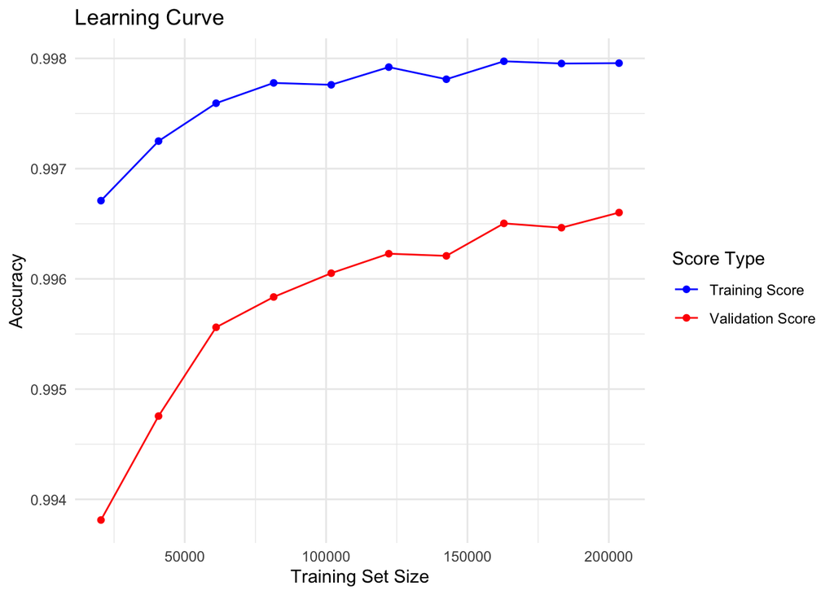

```r
# 7.1 Create a function to plot learning curves
plot_learning_curve <- function(data, target, model_fn, train_sizes = seq(0.1, 1.0, by = 0.1)) {
  n <- nrow(data)
  train_scores <- numeric(length(train_sizes))
  test_scores <- numeric(length(train_sizes))

  # Create a validation set
  set.seed(123)
  indices <- sample(1:n, size = n * 0.8)
  train_full <- data[indices, ]
  validation <- data[-indices, ]

  for (i in seq_along(train_sizes)) {
    # Take a subset of the training data
    size <- floor(train_sizes[i] * nrow(train_full))
    train_subset <- train_full[1:size, ]

    # Train model
    model <- model_fn(train_subset)

    # Evaluate on training and validation
    train_pred <- predict(model, data = train_subset)
    train_scores[i] <- sum(train_pred$predictions == train_subset[[target]]) / nrow(train_subset)

    val_pred <- predict(model, data = validation)
    test_scores[i] <- sum(val_pred$predictions == validation[[target]]) / nrow(validation)
  }

  # Create plot data
  plot_data <- data.frame(
    TrainSize = train_sizes * nrow(train_full),
    TrainScore = train_scores,
    ValidationScore = test_scores
  )

  # Plot
  ggplot(plot_data, aes(x = TrainSize)) +
    geom_line(aes(y = TrainScore, color = "Training Score")) +
    geom_line(aes(y = ValidationScore, color = "Validation Score")) +
    geom_point(aes(y = TrainScore, color = "Training Score")) +
    geom_point(aes(y = ValidationScore, color = "Validation Score")) +
    scale_color_manual(values = c("Training Score" = "blue", "Validation Score" = "red")) +
    labs(title = "Learning Curve",
         x = "Training Set Size",
         y = "Accuracy",
         color = "Score Type") +
    theme_minimal()
}

# 7.2 Define model function for ranger
ranger_fn <- function(data) {
  ranger(
    class ~ .,
    data = data,
    num.trees = 50,  # Reduced for speed
    mtry = floor(sqrt(ncol(data) - 1)),
    min.node.size = 5
  )
}

# 7.3 Plot learning curve
plot_learning_curve(train_imputed_reduced, "class", ranger_fn)
```

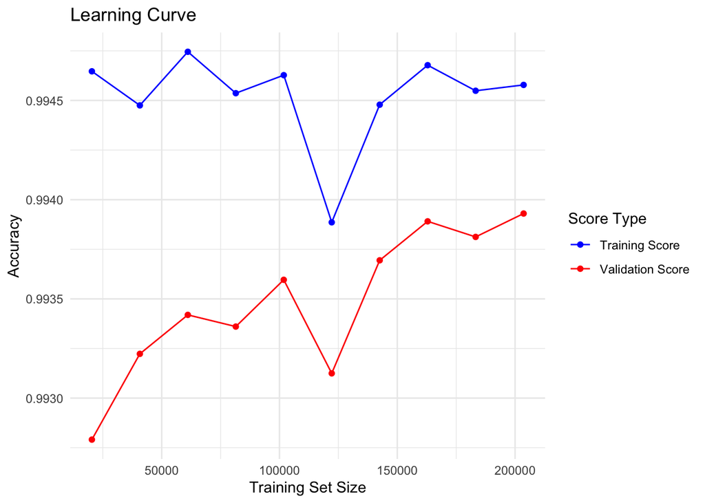

```r
# Compare with a smaller feature set
# Select just a few key features for a simpler model
key_features <- c("protocol_type", "service", "flag", "src_bytes", "dst_bytes", "logged_in")
train_simple <- train_imputed[, c(key_features, "class"), with = FALSE]

# Plot learning curve with simple model
plot_learning_curve(train_simple, "class", ranger_fn)
```

### Step 8: Recommended Research Questions

Based on our analysis of potential data leakage and class imbalance, here are three focused research questions:

1. **How do protocol metadata features alone (protocol_type, service, flag) perform in detecting network attacks compared to traffic volume metrics?**
   - This question helps isolate the predictive power of categorical network attributes versus potentially leaky volume metrics.
2. **What are the distinctive patterns of minority attack classes that differentiate them from normal traffic and common attack types?**
   - Focuses on understanding rare attacks that might be overlooked due to class imbalance.
3. **Can temporal patterns in network connection features provide early warning signals for specific attack types?**
   - Investigates whether sequence patterns in the data could improve attack prediction before they fully develop.

These questions directly address the issues we’ve identified with potential data leakage and class imbalance while aligning with the project’s core objective of network intrusion detection.

## Implementations for the recommended approach

```r
# Additional implementations of the approaches you suggested:

# 1. Dimensionality reduction with PCA
using("stats")
# Only apply PCA to numeric features
pca_features <- prcomp(train_imputed[, ..numeric_cols], scale. = TRUE)
# Determine number of components that explain 95% of variance
variance_explained <- cumsum(pca_features$sdev^2 / sum(pca_features$sdev^2))
n_components <- which(variance_explained >= 0.95)[1]
# Create reduced feature set
pca_train <- predict(pca_features, train_imputed[, ..numeric_cols])[, 1:n_components]
pca_test <- predict(pca_features, test_imputed[, ..numeric_cols])[, 1:n_components]

# 2. Class balancing with SMOTE (for minority classes)
# This would be implemented for severely imbalanced classes

# 3. Different model architectures
# - Try simpler models like decision trees
# - Consider ensemble methods like XGBoost
# - Implement neural networks for complex pattern recognition
```